# ggplot2 Introduction

## 6.4 四维定量变量

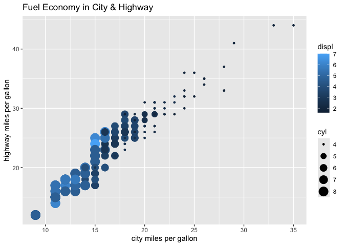

```r
#aes(cty,hwy,col =displ,size=cyl) displ映射颜色 cyl映射散点大小
mpg %>%
  ggplot(aes(cty,hwy,col = displ,size=cyl))+
  geom_point()+
    labs(title = "Fuel Economy in City & Highway",
  x = "city miles per gallon",
  y = "highway miles per gallon")
```

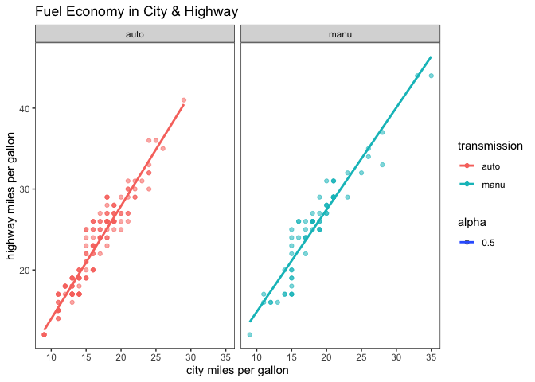

```r
mpg %>%
  ggplot(aes(cty,hwy,col = transmission,
             alpha=0.5))+
  geom_point()+
  geom_smooth(method = lm, se = F)+
  facet_wrap(~transmission)+
  theme_bw()+
  theme(panel.grid.major = element_blank(),
  panel.grid.minor = element_blank())+
  labs(title = "Fuel Economy in City & Highway",
  x = "city miles per gallon",
  y = "highway miles per gallon")
```

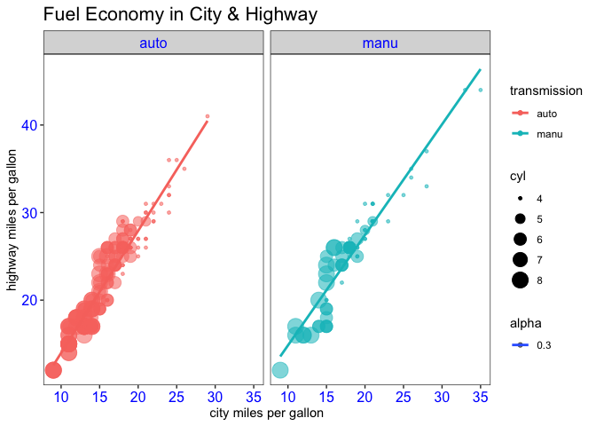

```r
mpg %>%
  ggplot(aes(cty,hwy,col = transmission,alpha=0.3))+
  geom_point(aes(size = cyl))+
  geom_smooth(method = lm, se = F)+
  facet_wrap(~transmission)+
  theme_bw()+
  theme(panel.grid.major = element_blank(),
  panel.grid.minor = element_blank())+
  labs(title = "Fuel Economy in City & Highway",
  x = "city miles per gallon",
  y = "highway miles per gallon")+
  theme(plot.title = element_text(size = 16),
        axis.text = element_text(color = "blue", size = 12),
        strip.text = element_text(color = "blue", size = 12))
```

# 7 本章习题

## 7.1 ggplot2 绘图: mpg

数据：mpg {ggplot2}

提示：mpg数据集在ggplot2这个包中，先加载ggplot2后，再运行?mpg，查看mpg的帮助文档。

注意：

在完成上述图形时，尽可能美化图形、完善坐标轴、图形标题、主题、颜色等的设置。

提交要求：先将图形都编辑到word文档，然后将word文档转换成图片提交。

利用ggplot2完成以下任务：

1. 任选一个定性变量，绘制条形图。
2. 任选两个定性变量，绘制分组条形图。
3. 任选一个定量变量，绘制直方图。
4. 任选一个定量变量，两个定性变量，绘制分组直方图。
5. 任选两个定量变量，绘制散点图，在散点图上添加趋势线。
6. 任选两个定量变量，绘制散点图，让散点的大小、颜色分别体现第3个、第4个变量的信息。
7. 任选两个定量变量，一个定性变量，绘制分组散点图，添加趋势线。
8. 任选一个定量变量，一个定性变量，绘制分组箱线图。

## 7.2 ggplot2 绘图:cellphone

数据：cellphone.xlsx 或者 cellphone.csv 变量含义： ID 序号；male:1,男，0，女；brand: 手机品牌；price: 手机价格；cost: 每月生活费

注意：

在完成上述图形时，尽可能美化图形、完善坐标轴、图形标题、主题、颜色等的设置。

提交要求：先将图形都编辑到word文档，然后将word文档转换成图片提交。

利用ggplot2完成以下任务：

1. 任选一个定性变量，绘制条形图。
2. 利用两个定性变量，绘制分组条形图。
3. 任选一个定量变量，绘制直方图。
4. 任选一个定量变量，一个定性变量，绘制分组直方图。
5. 利用两个定量变量，绘制散点图，在散点图上添加趋势线。
6. 利用两个定量变量，绘制散点图，让散点颜色代表某个定性变量的信息。
7. 利用两个定量变量，一个定性变量，绘制分组散点图，添加趋势线。
8. 利用一个定量变量，一个定性变量，绘制分组箱线图。